# Variáveis Aleatórias

# Questão 6

O exame de contagem de leucócitos é importante para detectar processos infecciosos. Suponha que a contagem de leucócitos de uma pessoa saudável pode ser aproximada por uma variável aleatória normal $𝑋$ de média $\mu$<sub>normal</sub> = 7250 e desvio padrão $\sigma$<sub>normal</sub> = 1500 e que a contagem de leucócitos de uma pessoa doente pode ser aproximada por uma variável aleatória $𝑌$ de média $\mu$<sub>doente</sub> = 15000 e desvio padrão $\sigma$<sub>doente</sub> = 2500. A figura abaixo ilustra a função densidade de probabilidade destas funções.

[figure not shown]

Suponha que o valor 10000 foi escolhido para distinguir pessoas saudáveis de pessoas doentes em um exame de sangue, conforme ilustrado na figura acima.

Nas questões a seguir mostre seus cálculos. Se usou o Python para efetuar cálculos, indique o comando utilizado.

**a)** Qual a probabilidade de que uma pessoa doente seja diagnosticada como saudável?

Trata-se da área em azul na imagem abaixo.

[figure not shown]

```python
from scipy.stats import norm
import numpy as np
```

```python
item_a = norm.cdf(10000, loc=15000, scale=2500)
item_a
```

```
0.022750131948179195
```

**b)** Quanto deveria ser o novo limiar para que houvesse no máximo uma probabilidade de 0.5% de uma pessoa doente não ser identificada? (Falso negativo)

Área vermelha deve conter 0,5%

[figure not shown]

```python
limiar = norm.ppf(.5/100, loc=15000, scale=2500)
limiar
```

```
8560.426741127747
```

**c)** No caso do limiar proposto no item acima, quanto seriam os falsos positivos? Ou seja, qual a probabilidade de uma pessoa não doente ser identificada como doente?

Seria área verde descrita na imagem abaixo.

[figure not shown]

```python
1-norm.cdf(limiar, loc=7250, scale=1500)
```

```
0.19116320716748014
```

# QUESTÃO 7

## Análise do ENEM

### Vamos investigar as notas do ENEM.

Esta parte da avaliação se baseia em uma amostra de dados do **ENEM 2017** adaptados para esta prova. O dicionario de dados encontra-se no link a seguir:

Dicionário de dados

```python
filename = "enem2017_30K.csv"
dados = pd.read_csv(filename, index_col=0)
dados.head(5)
```

|  | NU_INSCRICAO | SG_UF_RESIDENCIA | NU_IDADE | TP_SEXO | TP_ESTADO_CIVIL | TP_ST_CONCLUSAO | IN_TREINEIRO | NU_NOTA_CN | NU_NOTA_CH | NU_NOTA_LC | ... | CARRO | CELULAR | FIXO | COMPUTADOR | INTERNET | Q026 | TIPO_EM | RENDA | NOTA_TESTES | NOTA_ENEM |
| --- | --- | --- | --- | --- | --- | --- | --- | --- | --- | --- | --- | --- | --- | --- | --- | --- | --- | --- | --- | --- | --- |
| 171957 | 170003469518 | MT | 26.0 | F | 0.0 | 1 | 0 | 605.4 | 657.4 | 542.4 | ... | A | E | A | B | A | A | C | 3020.091575 | 2430.9 | 2990.9 |
| 127898 | 170005286919 | CE | 17.0 | M | 0.0 | 2 | 0 | 698.5 | 649.0 | 630.6 | ... | C | B | A | B | B | B | D | 3611.589780 | 2817.1 | 3677.1 |
| 132925 | 170005113172 | MA | 21.0 | M | 0.0 | 1 | 0 | 591.0 | 643.8 | 597.9 | ... | A | D | A | B | B | A | A | 1375.454182 | 2385.8 | 3325.8 |
| 119870 | 170005346442 | PR | 17.0 | F | 0.0 | 2 | 0 | 525.6 | 441.2 | 509.4 | ... | B | C | A | B | B | B | A | 2079.516469 | 1930.0 | 2450.0 |
| 122904 | 170004476042 | DF | 26.0 | F | 0.0 | 1 | 0 | 538.0 | 408.8 | 523.9 | ... | B | C | A | A | A | A | A | 1364.095119 | 1921.8 | 2381.8 |

5 rows × 28 columns

**a)** Visualize o histograma de densidade das notas do ENEM

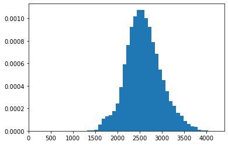

```python
plt.hist(dados.NOTA_ENEM, bins=50, density=True);
```

**b)** Verifique graficamente se a distribuição normal é um modelo adequado para as notas do ENEM. Apresente uma conclusão

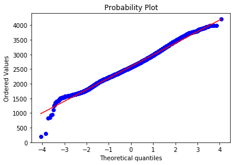

```python
stats.probplot(dados.NOTA_ENEM, dist="norm", plot=plt);
```

Conclusão: no probplot os dados estão bem alinhados à diagonal. É um bom ajuste. As discrepâncias estão bem longe do centro, que concentra a maior probabilidade

**c)** Supondo então que a distribuição normal é aceitável, realize o ajuste das notas do ENEM por uma normal.

```python
#Maneira 1
media = dados.NOTA_ENEM.mean()
dp = dados.NOTA_ENEM.std()
media, dp
```

```
(2591.8313599999997, 396.88945452000536)
```

```python
#Maneira 2
media, dp = stats.norm.fit(dados.NOTA_ENEM)
media, dp
```

```
(2591.8313599999997, 396.88283964063885)
```

**d)** Visualize a normal plotada no item acima sobre o histograma de densidade e avalie a qualidade do ajuste

```python
x_9 = np.linspace(500, 5000, 1000)
```

```python
y_9 = stats.norm.pdf(x_9, loc=media, scale=dp)
```

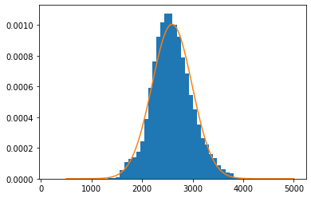

```python
plt.hist(dados.NOTA_ENEM, bins=50, density=True);
plt.plot(x_9, y_9)
```

R.: Na faixa de maior probabilidade o ajuste parece bom

**e)** Qual é o menor valor de nota do ENEM maior que $70\%$ das notas? Responda com base nos dados

```python
dados.NOTA_ENEM.quantile(.7)
```

```
2775.0
```

**f)** Baseado no ajuste que fez no item c, responda novamente à questão anterior agora usando o modelo probabilístico.

```python
norm.ppf(.7, loc=media, scale=dp)
```

```
2799.9569245925736
```